# MATH 2310 Lab 4

Gary Tou

# Introduction

In this lab you will explore another data set about vehicle performance very similar to to the data set we looked at in class for Lab 3. You will use the tools developed in the course so far to explore the data and then build some predictions for data that you have yet to see.

# Import Libraries

Below are some packages you may want to use. ISLR2 is a new package you will need to obtain the data for this problem. Install the packages first but don’t include the install command in your knited document. You only need to run the install command once, then just run the library function each time you run you script.

```r
#install.packages('tidyverse', 'GGally','rstatix','Stat2Data','ggpubr') #Run this code once.
library(tidyverse)
library(rstatix)
library(Stat2Data)
library(ggpubr)
library(GGally)
library(ISLR2)
```

# Load the Data

Once you have loaded the ISLR2 package, the data set we will use is called Auto

```r
df = Auto
df$origin <- as.factor(df$origin) #Convert this column to a factor.
df$year <- as.ordered(df$year) #Convert this column to an ordered factor.
levels(df$origin)<-c('American', 'European', 'Asian') #This will assign the lables their value instead of the number.
```

# Explore the data

## **Question 1**

**Look up `Auto` in the help to see a description of the data (You don’t need to show any R code, but you should write some text to summarize what you see). State clearly which variables in the data set are numeric (continuous/discrete) and which are categorical (nominal/ordinal).**

### **Answer**

The Auto Data Set by `ISLR2` contains the gas mileage, horpower, and other information for 392 vehicles.

## **Question 2**

**View a few rows of the data set.**

**Review the summary of each of the numeric variables and summarize any observations about the skew.**

### **Answer**

```r
head(df)
```

|  | mpg | cylinders | displacement | horsepower | weight | acceleration | year | origin | name |
| --- | --- | --- | --- | --- | --- | --- | --- | --- | --- |
| 1 | 18 | 8 | 307 | 130 | 3504 | 12.0 | 70 | American | chevrolet chevelle malibu |
| 2 | 15 | 8 | 350 | 165 | 3693 | 11.5 | 70 | American | buick skylark 320 |
| 3 | 18 | 8 | 318 | 150 | 3436 | 11.0 | 70 | American | plymouth satellite |
| 4 | 16 | 8 | 304 | 150 | 3433 | 12.0 | 70 | American | amc rebel sst |
| 5 | 17 | 8 | 302 | 140 | 3449 | 10.5 | 70 | American | ford torino |
| 6 | 15 | 8 | 429 | 198 | 4341 | 10.0 | 70 | American | ford galaxie 500 |

```r
summary(df)
```

```
##       mpg          cylinders      displacement     horsepower        weight
##  Min.   : 9.00   Min.   :3.000   Min.   : 68.0   Min.   : 46.0   Min.   :1613
##  1st Qu.:17.00   1st Qu.:4.000   1st Qu.:105.0   1st Qu.: 75.0   1st Qu.:2225
##  Median :22.75   Median :4.000   Median :151.0   Median : 93.5   Median :2804
##  Mean   :23.45   Mean   :5.472   Mean   :194.4   Mean   :104.5   Mean   :2978
##  3rd Qu.:29.00   3rd Qu.:8.000   3rd Qu.:275.8   3rd Qu.:126.0   3rd Qu.:3615
##  Max.   :46.60   Max.   :8.000   Max.   :455.0   Max.   :230.0   Max.   :5140
##
##   acceleration        year          origin                    name
##  Min.   : 8.00   73     : 40   American:245   amc matador       :  5
##  1st Qu.:13.78   78     : 36   European: 68   ford pinto        :  5
##  Median :15.50   76     : 34   Asian   : 79   toyota corolla    :  5
##  Mean   :15.54   75     : 30                  amc gremlin       :  4
##  3rd Qu.:17.02   82     : 30                  amc hornet        :  4
##  Max.   :24.80   70     : 29                  chevrolet chevette:  4
##                  (Other):193                  (Other)           :365
```

```r
for (i in 1:6) {
  print(names(df)[i])
  print(summary(df[,i]))
  lhs <- median(df[,i]) - quantile(df[,i], 0.25)
  rhs <- quantile(df[,i], 0.75) - median(df[,i])
  print(paste("Left (Q1-median):", lhs))
  print(paste("Right (median-Q3):", rhs))
  writeLines("\n\n")
}
```

```
## [1] "mpg"
##    Min. 1st Qu.  Median    Mean 3rd Qu.    Max.
##    9.00   17.00   22.75   23.45   29.00   46.60
## [1] "Left (Q1-median): 5.75"
## [1] "Right (median-Q3): 6.25"
##
##
##
## [1] "cylinders"
##    Min. 1st Qu.  Median    Mean 3rd Qu.    Max.
##   3.000   4.000   4.000   5.472   8.000   8.000
## [1] "Left (Q1-median): 0"
## [1] "Right (median-Q3): 4"
##
##
##
## [1] "displacement"
##    Min. 1st Qu.  Median    Mean 3rd Qu.    Max.
##    68.0   105.0   151.0   194.4   275.8   455.0
## [1] "Left (Q1-median): 46"
## [1] "Right (median-Q3): 124.75"
##
##
##
## [1] "horsepower"
##    Min. 1st Qu.  Median    Mean 3rd Qu.    Max.
##    46.0    75.0    93.5   104.5   126.0   230.0
## [1] "Left (Q1-median): 18.5"
## [1] "Right (median-Q3): 32.5"
##
##
##
## [1] "weight"
##    Min. 1st Qu.  Median    Mean 3rd Qu.    Max.
##    1613    2225    2804    2978    3615    5140
## [1] "Left (Q1-median): 578.25"
## [1] "Right (median-Q3): 811.25"
##
##
##
## [1] "acceleration"
##    Min. 1st Qu.  Median    Mean 3rd Qu.    Max.
##    8.00   13.78   15.50   15.54   17.02   24.80
## [1] "Left (Q1-median): 1.725"
## [1] "Right (median-Q3): 1.525"
```

The first few rows can be seen above (using the `head` command).

All numeric variables, except `acceleration`, seem to be **Right Skewed** since the Median is closer to Q1. `acceleration`, is **Left Skewed** instead.

# Single variable investigation

## **Question 3**

- **Make histograms for mpg, displacement, horsepower weight, and acceleration. Make sure to set the number of bins appropriately.**
- **Make box plots for mpg, displacement, horsepower, weight, and acceleration. Include any observations.**
- **Find any outliers for each of mpg, displacement, horsepower, weight, or acceleration.**
- **Summarize your findings for each variable.**

### **Answer**

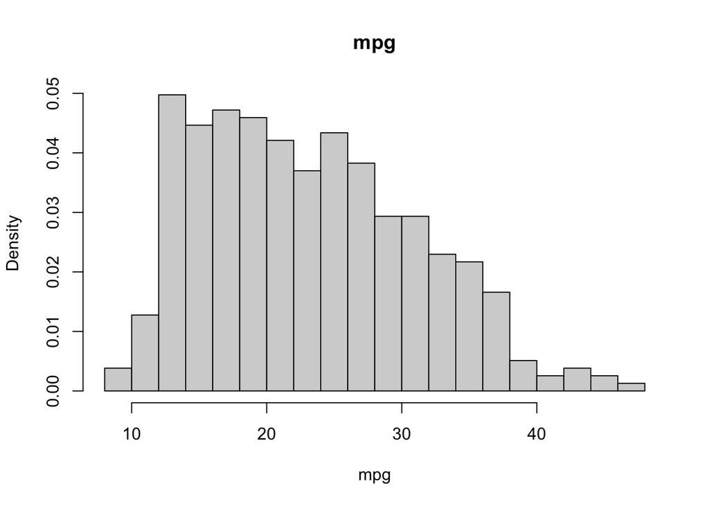

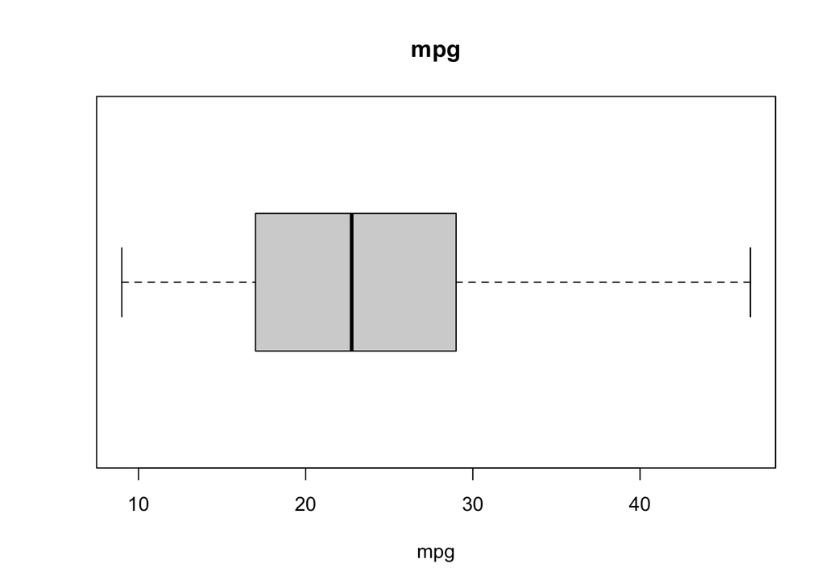

```
##  [1] mpg          cylinders    displacement horsepower   weight
##  [6] acceleration year         origin       name         is.outlier
## [11] is.extreme
## <0 rows> (or 0-length row.names)
```

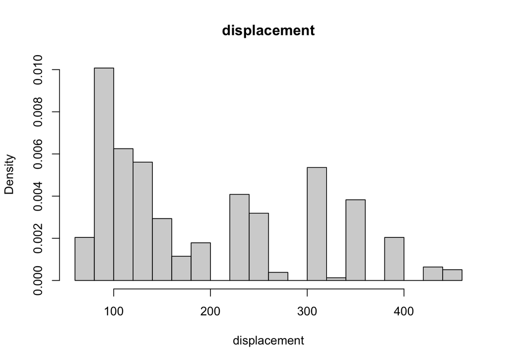

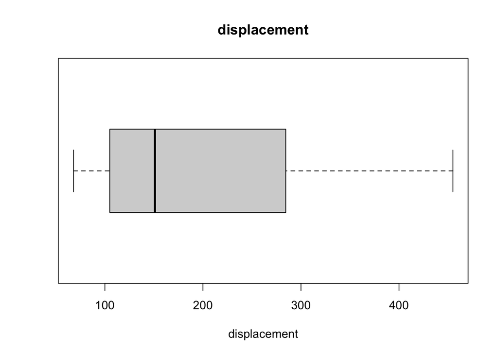

```
##  [1] mpg          cylinders    displacement horsepower   weight
##  [6] acceleration year         origin       name         is.outlier
## [11] is.extreme
## <0 rows> (or 0-length row.names)
```

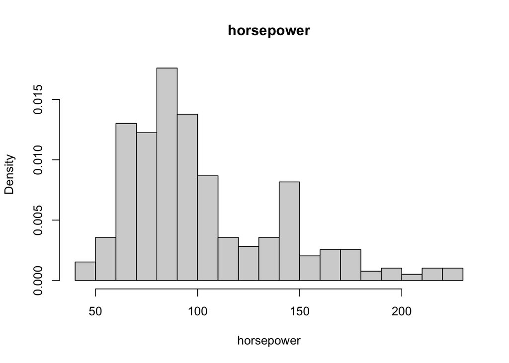

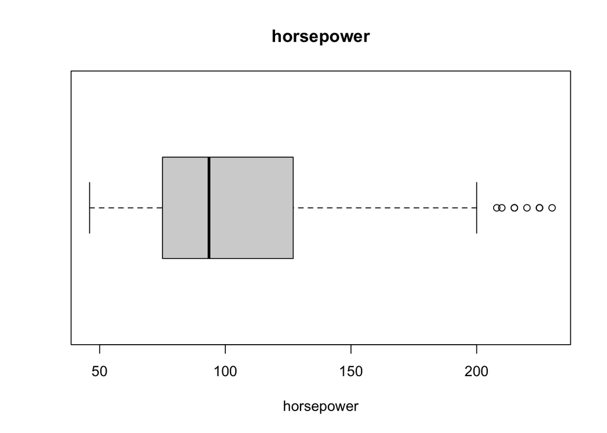

```
##    mpg cylinders displacement horsepower weight acceleration year   origin
## 1   14         8          454        220   4354          9.0   70 American
## 2   14         8          440        215   4312          8.5   70 American
## 3   14         8          455        225   4425         10.0   70 American
## 4   14         8          455        225   3086         10.0   70 American
## 5   10         8          360        215   4615         14.0   70 American
## 6   11         8          318        210   4382         13.5   70 American
## 7   11         8          429        208   4633         11.0   72 American
## 8   13         8          440        215   4735         11.0   73 American
## 9   12         8          455        225   4951         11.0   73 American
## 10  16         8          400        230   4278          9.5   73 American
##                            name is.outlier is.extreme
## 1              chevrolet impala       TRUE      FALSE
## 2             plymouth fury iii       TRUE      FALSE
## 3              pontiac catalina       TRUE      FALSE
## 4       buick estate wagon (sw)       TRUE      FALSE
## 5                     ford f250       TRUE      FALSE
## 6                    dodge d200       TRUE      FALSE
## 7               mercury marquis       TRUE      FALSE
## 8  chrysler new yorker brougham       TRUE      FALSE
## 9      buick electra 225 custom       TRUE      FALSE
## 10           pontiac grand prix       TRUE      FALSE
```

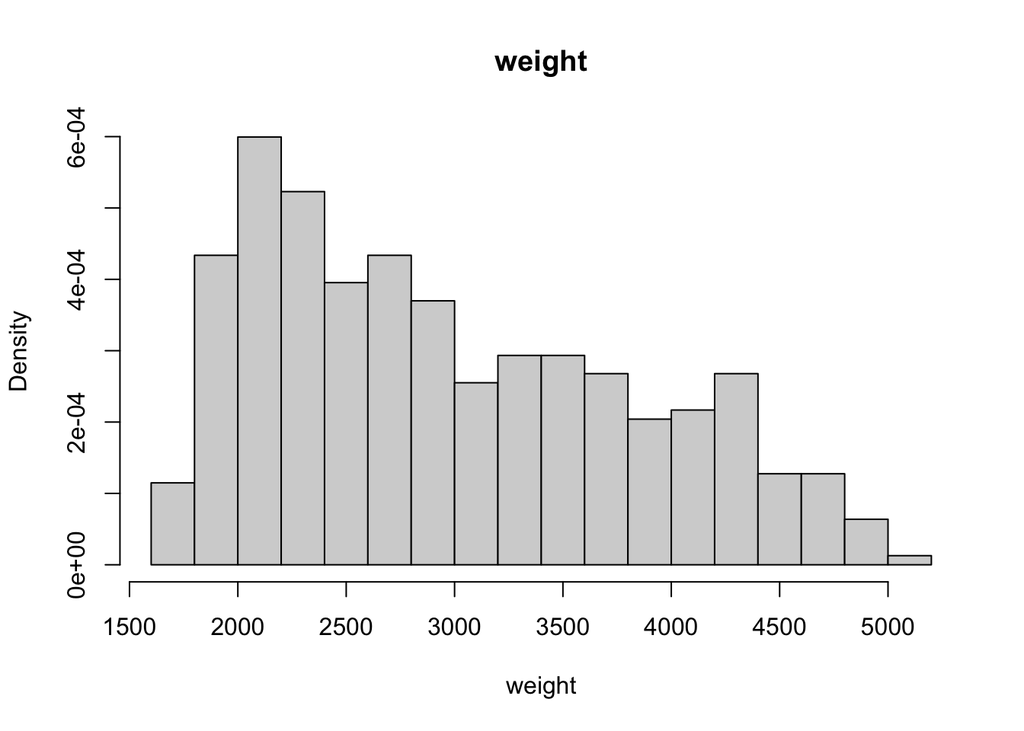

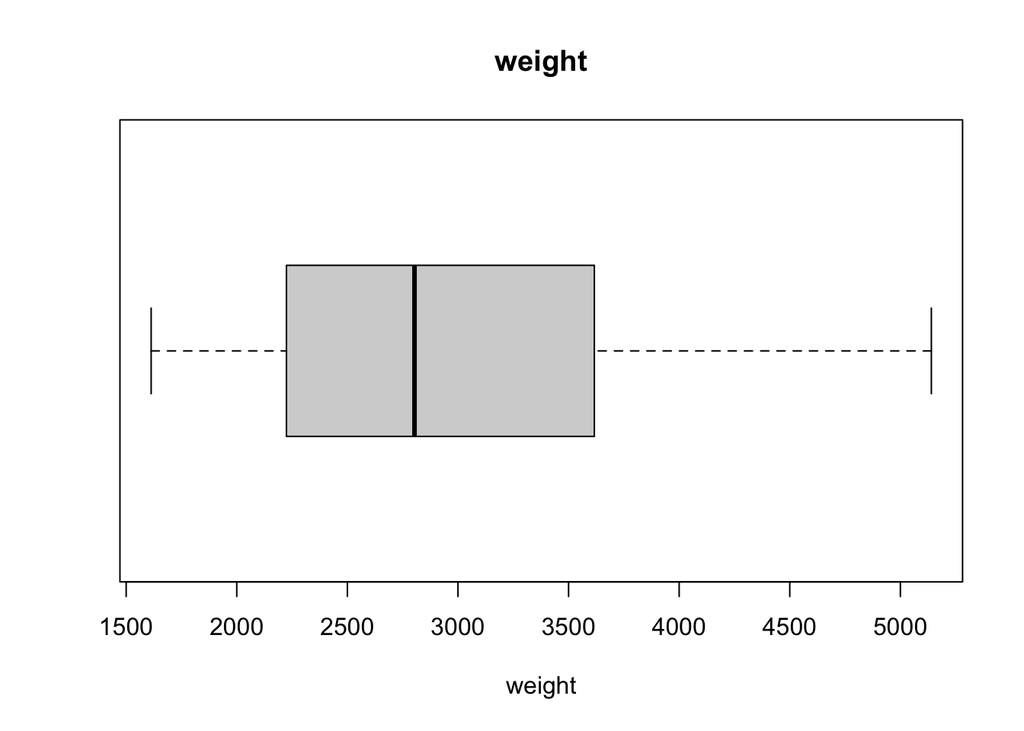

```
##  [1] mpg          cylinders    displacement horsepower   weight
##  [6] acceleration year         origin       name         is.outlier
## [11] is.extreme
## <0 rows> (or 0-length row.names)
```

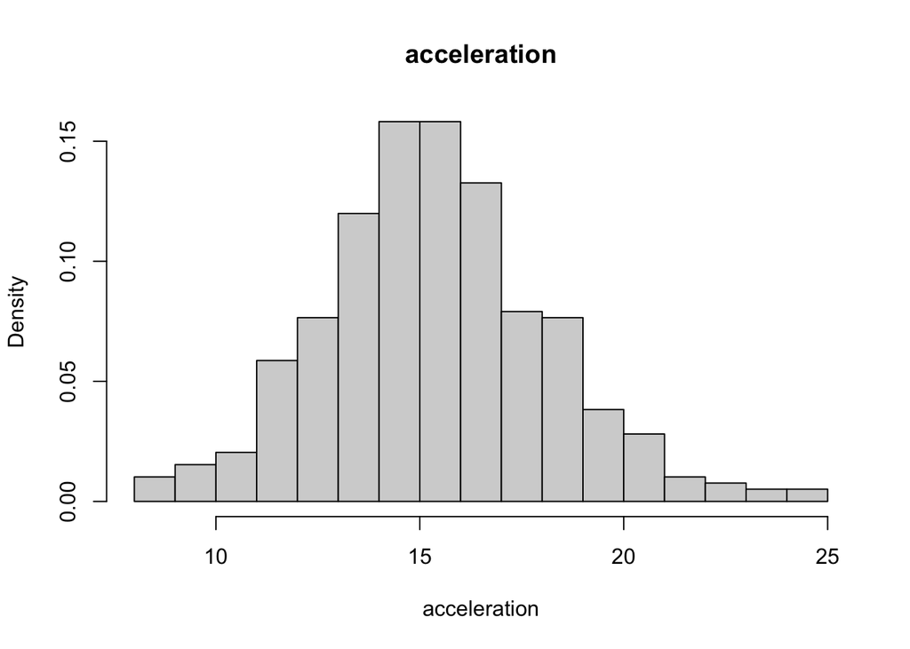

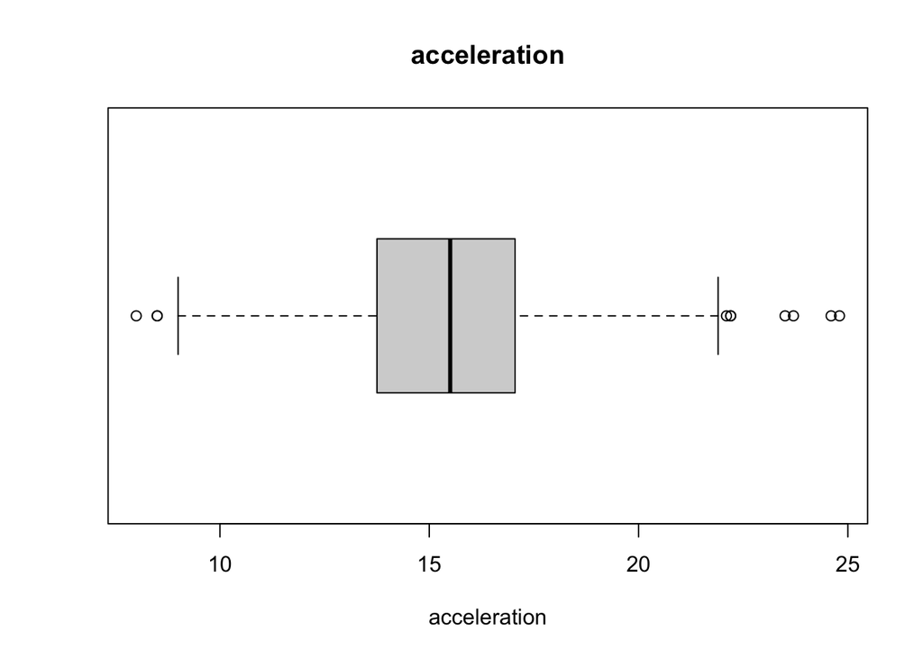

```
##     mpg cylinders displacement horsepower weight acceleration year   origin
## 1  14.0         8          440        215   4312          8.5   70 American
## 2  15.0         8          390        190   3850          8.5   70 American
## 3  14.0         8          340        160   3609          8.0   70 American
## 4  23.0         4           97         54   2254         23.5   72 European
## 5  29.0         4           85         52   2035         22.2   76 American
## 6  24.5         4           98         60   2164         22.1   76 American
## 7  19.0         4          120         88   3270         21.9   76 European
## 8  27.2         4          141         71   3190         24.8   79 European
## 9  23.9         8          260         90   3420         22.2   79 American
## 10 43.4         4           90         48   2335         23.7   80 European
## 11 44.0         4           97         52   2130         24.6   82 European
##                                 name is.outlier is.extreme
## 1                  plymouth fury iii       TRUE      FALSE
## 2                 amc ambassador dpl       TRUE      FALSE
## 3                 plymouth 'cuda 340       TRUE      FALSE
## 4                  volkswagen type 3       TRUE      FALSE
## 5                 chevrolet chevette       TRUE      FALSE
## 6                    chevrolet woody       TRUE      FALSE
## 7                        peugeot 504       TRUE      FALSE
## 8                        peugeot 504       TRUE      FALSE
## 9  oldsmobile cutlass salon brougham       TRUE      FALSE
## 10                vw dasher (diesel)       TRUE      FALSE
## 11                         vw pickup       TRUE      FALSE
```

```r
histdat = df %>% select(mpg, displacement, horsepower, weight, acceleration)

bins = round(sqrt(nrow(histdat)))

for (i in 1:5) {
  hist(histdat[,i], breaks=bins, freq=FALSE,
       main=paste0(names(histdat)[i]),
       xlab=paste0(names(histdat)[i]))

  boxplot(histdat[,i], breaks=bins, freq=FALSE,
       main=paste0(names(histdat)[i]),
       xlab=paste0(names(histdat)[i]),
       horizontal = TRUE)

  outliers = df %>% identify_outliers(names(histdat)[i]) %>% arrange(names(histdat)[i])

  print(outliers)
}
```

The proper number of bins is 20.

#### `mpg`

- Unimodal
- Right skewed
- No outliers

#### `displacement`

- Bimodal (although the data is noisy)
- Right skewed
- No outliers

#### `horsepower`

- Unimodal
- Right skewed
- Many outliers on the higher end (more horsepower)

#### `weight`

- Unimodal
- Right skewed
- No outliers

#### `acceleration`

- Unimodal
- Fairly symmetrical
- Outliers on both ends, however, majority are on the higher end (more acceleration)

# Multiple Variable Comparison

## **Question 4**

**On a single graph create a box plot for mpg for each year. Included jittered points. Explain what you see and develop a hypothosis of why the behavior you observe makes sense.**

### **Answer**

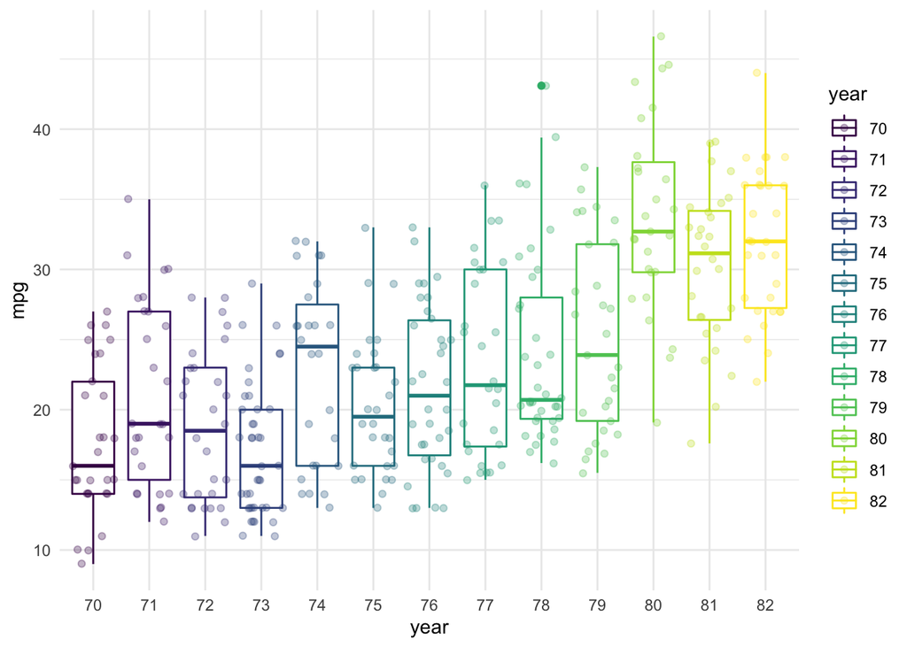

```r
ggplot(df,  aes(x=year, y = mpg, color=year)) + #Format (dataset, aes(x= xvaraible, y=yvariable, color= color variable))
    geom_boxplot() + #plot type
    geom_jitter(alpha=.3) + #add jitter, alpha controls the opacity of the jitter points
    theme_minimal()
```

## **Question 5**

**On a single graph create a box plot for mpg for each value of the origin variable. Explain what you see and develop a hypothosis of why the behavior you observe makes sense.**

### **Answer**

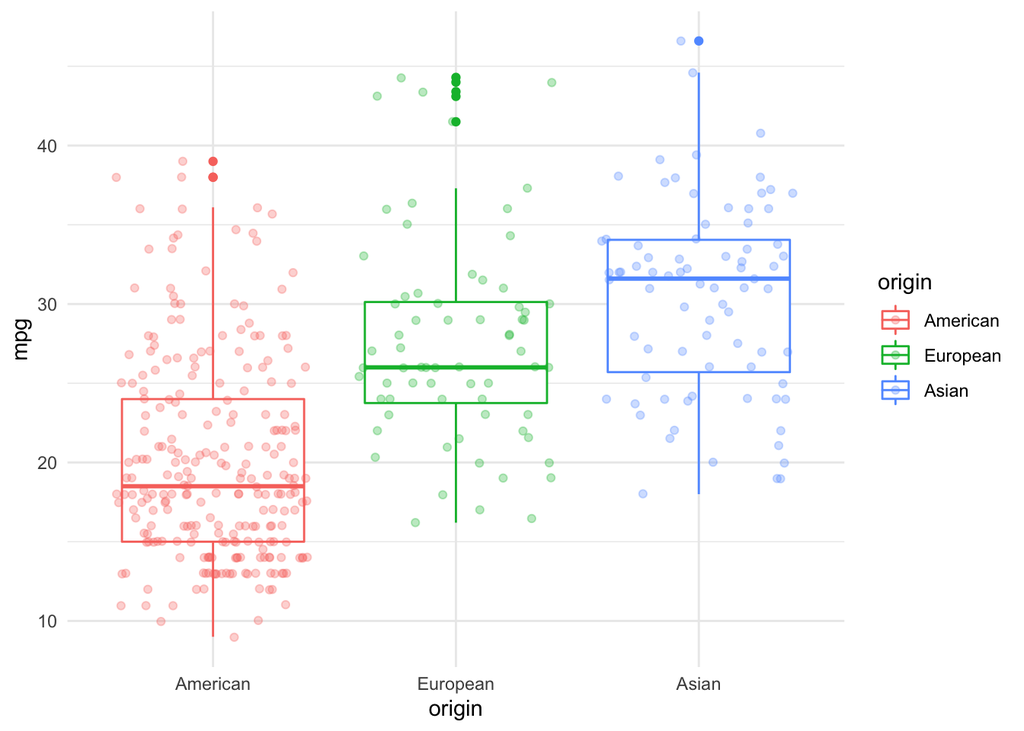

```r
ggplot(df,  aes(x=origin, y = mpg, color=origin)) + #Format (dataset, aes(x= xvaraible, y=yvariable, color= color variable))
    geom_boxplot() + #plot type
    geom_jitter(alpha=.3) + #add jitter, alpha controls the opacity of the jitter points
    theme_minimal()
```

Vehicles from `Asia` have higher `mpg` compared to vehicles from `Europe` and `America`. The order in descending `mpg` is:

1. Asian
2. European
3. American

## **Question 6**

**Create a scatter plot of mpg with acceleration. Explain what you see.**

### **Answer**

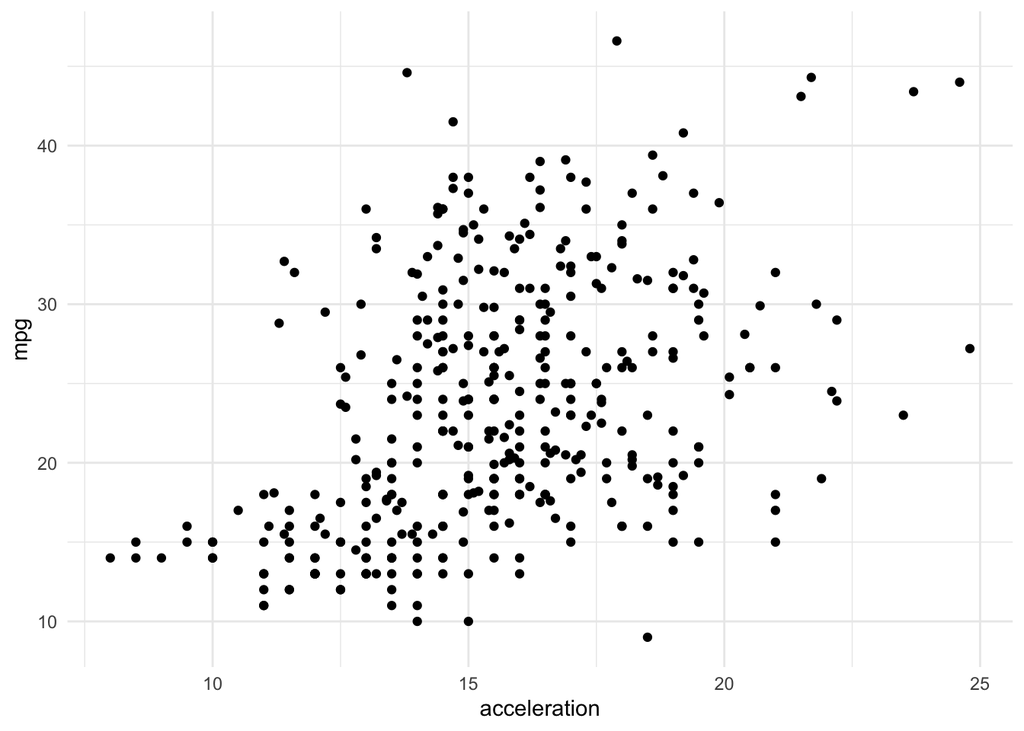

```r
#Use ggplot to create the scatter plot.
ggplot(df,  aes(x = acceleration,y=mpg))+  #Format (dataset, aes(x= xvaraible, y=yvariable))
    geom_point()+ # this says to plot points
    theme_minimal() # This is optional
```

# Regression

## **Question 7**

- **Calculate the correlation for each pair of numeric variables. Find the variable that is the most correlated to mpg. Also find the variable that is the second-most correlated with mpg.**
- **For each of the two variables found in the step above, create separate regression equations predicting miles per gallon using each variable. Show the equation, the $r^2$, the standard deviation of the residuals. Then create a scatter plot for each including the regression line plot. You should have two of everything - equation, $r^2$, standard deviations, and plots.**
- **Explain which of the two regressions you think is better and why.**
- **In words explain why using multiple regression might be better in this case.**

### **Answer**

```r
cor(df %>% select_if(is.numeric))
```

```
##                     mpg  cylinders displacement horsepower     weight
## mpg           1.0000000 -0.7776175   -0.8051269 -0.7784268 -0.8322442
## cylinders    -0.7776175  1.0000000    0.9508233  0.8429834  0.8975273
## displacement -0.8051269  0.9508233    1.0000000  0.8972570  0.9329944
## horsepower   -0.7784268  0.8429834    0.8972570  1.0000000  0.8645377
## weight       -0.8322442  0.8975273    0.9329944  0.8645377  1.0000000
## acceleration  0.4233285 -0.5046834   -0.5438005 -0.6891955 -0.4168392
##              acceleration
## mpg             0.4233285
## cylinders      -0.5046834
## displacement   -0.5438005
## horsepower     -0.6891955
## weight         -0.4168392
## acceleration    1.0000000
```

```
## [1] "Equation: y = -0.00764734253577958x + 46.2165245490176"
## [1] "R^2: 0.692630433120626"
## [1] "Standard Deviation of Residuals: 4.33271209733946"
##
## Call:
## lm(formula = y ~ x, data = df)
##
## Residuals:
##      Min       1Q   Median       3Q      Max
## -11.9736  -2.7556  -0.3358   2.1379  16.5194
##
## Coefficients:
##              Estimate Std. Error t value Pr(>|t|)
## (Intercept) 46.216524   0.798673   57.87   <2e-16 ***
## x           -0.007647   0.000258  -29.64   <2e-16 ***
## ---
## Signif. codes:  0 '***' 0.001 '**' 0.01 '*' 0.05 '.' 0.1 ' ' 1
##
## Residual standard error: 4.333 on 390 degrees of freedom
## Multiple R-squared:  0.6926, Adjusted R-squared:  0.6918
## F-statistic: 878.8 on 1 and 390 DF,  p-value: < 2.2e-16
```

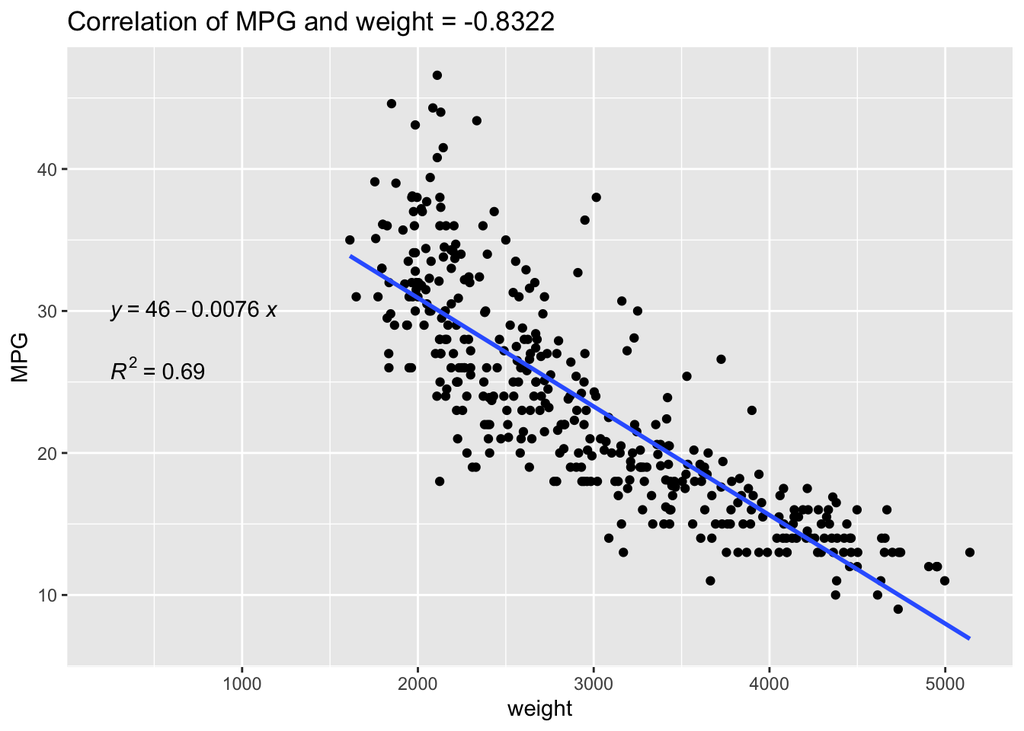

```r
# The most correlated with mpg are weight and displacement.

var_regression <- function(var_name) {
  df$x = df[, c(var_name)]
  df$y = df$mpg

  lsfit = lm(y ~ x, data=df)
  lsfit

  s = summary(lsfit)

  print(paste0("Equation: y = ", lsfit$coefficients[[2]], "x + ", lsfit$coefficients[[1]]))
  print(paste("R^2:", s$r.squared))
  print(paste("Standard Deviation of Residuals:", s$sigma))

  print(s)

  ggplot(df, aes(x=x, y=y)) + #Sames as before (data, aes(x, y))
    geom_point() + #plot points
    geom_smooth(method="lm",se = FALSE)+ #plot the lm line
    stat_regline_equation(label.x=250, label.y=30)+ # creates the equation and puts it at the coordinates
    stat_cor(aes(label=..rr.label..), label.x=250, label.y=26)+ #creates the r^2 and puts it at the coordinates
    labs(y='MPG', x=var_name)+ #labels the axes
    ggtitle(paste('Correlation of MPG and', var_name, '=', round(cor(df$y, df$x),4) )) #creates a title
}

var_regression("weight")
```

```r
var_regression("displacement")
```

```
## [1] "Equation: y = -0.0600514278122063x + 35.1206359384039"
## [1] "R^2: 0.648229400319304"
## [1] "Standard Deviation of Residuals: 4.6351006451931"
##
## Call:
## lm(formula = y ~ x, data = df)
##
## Residuals:
##      Min       1Q   Median       3Q      Max
## -12.9170  -3.0243  -0.5021   2.3512  18.6128
##
## Coefficients:
##             Estimate Std. Error t value Pr(>|t|)
## (Intercept) 35.12064    0.49443   71.03   <2e-16 ***
## x           -0.06005    0.00224  -26.81   <2e-16 ***
## ---
## Signif. codes:  0 '***' 0.001 '**' 0.01 '*' 0.05 '.' 0.1 ' ' 1
##
## Residual standard error: 4.635 on 390 degrees of freedom
## Multiple R-squared:  0.6482, Adjusted R-squared:  0.6473
## F-statistic: 718.7 on 1 and 390 DF,  p-value: < 2.2e-16
```

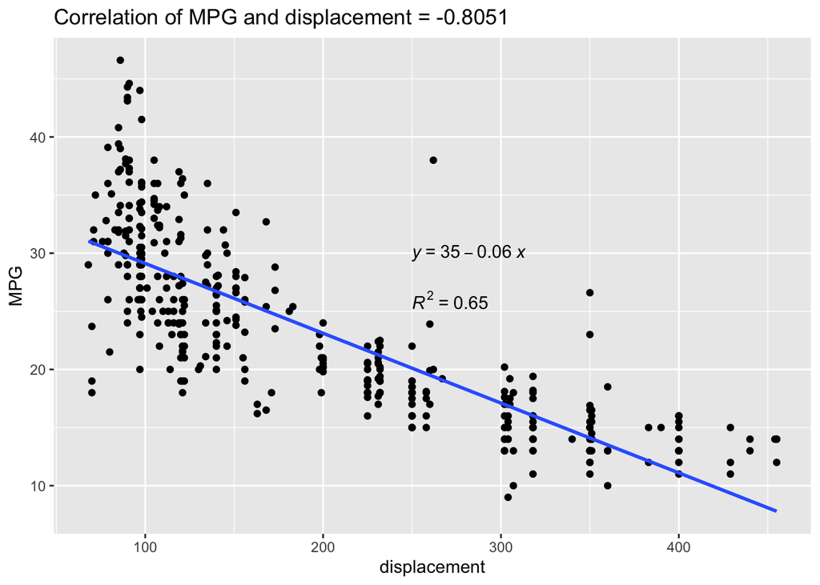

The better regression is MPG and weight because it has a higher $R^2$ value. A $R^2$ value of 1 would indicate a perfect model. Therefore, a higher $R^2$ value is reason to believe that one regression model is better than another. In this case, the MPG and Weight regression has a $R^2=0.69$ while MPG and displacement’s $R^2=0.65$. Therefore, MPG and weight is a better regression.

Multiple regressions essentially provide us with more data to formula the regression. With the addition of more variables, it allows us to create a closer fitting and more accurate regression. In this case, The multiple regression could be composed of both weight and displacement. In that case, it would theoretically provide us with a better predictor of MPG given weight and displacement as inputs.